# Logistic Regression for Binary Classification

# 1 Objective

# 2 Credit Card Default Data

We will use a subset of Credit Card Default Data (sample size n=12,000) for this lab and illustration. The details of the full data (n=30,000) can be found at http://archive.ics.uci.edu/ml/datasets/default+of+credit+card+clients. Think about what kind of factors could affect people to fail to pay their credit balance.

We first load the credit scoring data. It is easy to load comma-separated values (CSV).

```r
credit.data <- read.csv(file = "https://yanyudm.github.io/Data-Mining-R/lecture/data/credit_default.csv", header=T)
```

Look at what information do we have.

```r
colnames(credit.data)
```

```
##  [1] "LIMIT_BAL"                  "SEX"
##  [3] "EDUCATION"                  "MARRIAGE"
##  [5] "AGE"                        "PAY_0"
##  [7] "PAY_2"                      "PAY_3"
##  [9] "PAY_4"                      "PAY_5"
## [11] "PAY_6"                      "BILL_AMT1"
## [13] "BILL_AMT2"                  "BILL_AMT3"
## [15] "BILL_AMT4"                  "BILL_AMT5"
## [17] "BILL_AMT6"                  "PAY_AMT1"
## [19] "PAY_AMT2"                   "PAY_AMT3"
## [21] "PAY_AMT4"                   "PAY_AMT5"
## [23] "PAY_AMT6"                   "default.payment.next.month"
```

Let’s look at how many people were actually default in this sample.

```r
mean(credit.data$default.payment.next.month)
```

```
## [1] 0.2193333
```

The name of response variable is too long! I want to make it shorter by renaming. Recall the `rename()` function.

```r
library(dplyr)
credit.data<- rename(credit.data, default=default.payment.next.month)
```

How about the variable type and summary statistics?

```r
str(credit.data)    # structure - see variable type
summary(credit.data) # summary statistics
```

[output not shown]

We see all variables are **int**, but we know that *SEX, EDUCATION, MARRIAGE* are categorical, we convert them to **factor**.

```r
credit.data$SEX<- as.factor(credit.data$SEX)
credit.data$EDUCATION<- as.factor(credit.data$EDUCATION)
credit.data$MARRIAGE<- as.factor(credit.data$MARRIAGE)
```

*We omit other EDA, but you shouldn’t whenever you are doing data analysis.*

go to top

# 3 Logistic Regression

Randomly split the data to training (80%) and testing (20%) datasets:

```r
index <- sample(nrow(credit.data),nrow(credit.data)*0.80)
credit.train = credit.data[index,]
credit.test = credit.data[-index,]
```

## 3.1 Train a logistic regression model with all variables

```r
credit.glm0<- glm(default~., family=binomial, data=credit.train)
summary(credit.glm0)
```

```
##
## Call:
## glm(formula = default ~ ., family = binomial, data = credit.train)
##
## Deviance Residuals:
##     Min       1Q   Median       3Q      Max
## -3.1465  -0.6921  -0.5340  -0.2835   3.0236
##
## Coefficients:
##               Estimate Std. Error z value Pr(>|z|)
## (Intercept) -9.584e-01  1.538e-01  -6.232 4.61e-10 ***
## LIMIT_BAL   -1.042e-06  2.864e-07  -3.636 0.000276 ***
## SEX2        -1.887e-01  5.465e-02  -3.452 0.000556 ***
## EDUCATION2  -1.461e-01  6.355e-02  -2.299 0.021528 *
## EDUCATION3  -2.073e-01  8.570e-02  -2.419 0.015552 *
## EDUCATION4  -1.193e+00  3.216e-01  -3.710 0.000207 ***
## MARRIAGE2   -1.862e-01  6.179e-02  -3.013 0.002589 **
## MARRIAGE3   -1.528e-02  2.325e-01  -0.066 0.947610
## AGE          6.469e-03  3.328e-03   1.944 0.051904 .
## PAY_0        6.085e-01  3.154e-02  19.291  < 2e-16 ***
## PAY_2        4.000e-02  3.621e-02   1.105 0.269309
## PAY_3        5.711e-02  3.996e-02   1.429 0.152934
## PAY_4        4.945e-02  4.495e-02   1.100 0.271276
## PAY_5        5.700e-02  4.811e-02   1.185 0.236114
## PAY_6        8.142e-03  3.976e-02   0.205 0.837733
## BILL_AMT1   -4.351e-06  1.877e-06  -2.318 0.020472 *
## BILL_AMT2    1.804e-06  2.497e-06   0.722 0.470009
## BILL_AMT3    2.215e-06  2.259e-06   0.980 0.326937
## BILL_AMT4   -3.198e-06  2.496e-06  -1.281 0.200179
## BILL_AMT5    2.587e-06  2.762e-06   0.937 0.348858
## BILL_AMT6   -8.660e-08  2.150e-06  -0.040 0.967868
## PAY_AMT1    -6.605e-06  3.176e-06  -2.080 0.037570 *
## PAY_AMT2    -8.208e-06  3.354e-06  -2.447 0.014401 *
## PAY_AMT3    -3.552e-06  3.408e-06  -1.042 0.297261
## PAY_AMT4    -3.121e-06  2.938e-06  -1.062 0.288047
## PAY_AMT5    -2.152e-06  3.047e-06  -0.706 0.480089
## PAY_AMT6    -2.714e-06  2.156e-06  -1.259 0.208040
## ---
## Signif. codes:  0 '***' 0.001 '**' 0.01 '*' 0.05 '.' 0.1 ' ' 1
##
## (Dispersion parameter for binomial family taken to be 1)
##
##     Null deviance: 10045.3  on 9599  degrees of freedom
## Residual deviance:  8766.3  on 9573  degrees of freedom
## AIC: 8820.3
##
## Number of Fisher Scoring iterations: 5
```

You have seen `glm()` before. In this lab, this is the main function used to build logistic regression model because it is a member of generalized linear model. In `glm()`, the only thing new is `family`. It specifies the distribution of your response variable. You may also specify the link function after the name of distribution, for example, `family=binomial(logit)` (default link is logit). You can also specify `family=binomial(link = "probit")` to run probit regression. You may also use `glm()` to build many other generalized linear models.

## 3.2 Binary Classification

As we talked in the lecture, people may be more interested in the classification results. But we have to define a cut-off probability first.

These tables illustrate the impact of choosing different cut-off probability. Choosing a large cut-off probability will result in few cases being predicted as 1, and chossing a small cut-off probability will result in many cases being predicted as 1.

```r
pred.glm0.train <- predict(credit.glm0, type="response")

table((pred.glm0.train > 0.9)*1)
```

```
##
##    0    1
## 9574   26
```

```r
table((pred.glm0.train > 0.5)*1)
```

```
##
##    0    1
## 8868  732
```

```r
table((pred.glm0.train > 0.2)*1)
```

```
##
##    0    1
## 5293 4307
```

```r
table((pred.glm0.train > 0.0001)*1)
```

```
##
##    0    1
##    1 9599
```

Therefore, determine the optimal cut-off probability is crucial. The simplest way to determine the cut-off is to use the proportion of “1” in the original data. We will intriduce a more appropriate way to determine the optimal p-cut.

### 3.2.1 Naive Choice of Cut-off probability

The simplest way is to choose the event proportion in training sample. This is roughly reasonable because the sample proportion is an estimate of mean probability of $Y=1$.

```r
pcut1<- mean(credit.train$default)
```

Based on this cut-off probability, we can obtain the binary prediction (predicted classification) and the confusion matrix

```r
# get binary prediction
class.glm0.train<- (pred.glm0.train>pcut1)*1
# get confusion matrix
table(credit.train$default, class.glm0.train, dnn = c("True", "Predicted"))
```

```
##     Predicted
## True    0    1
##    0 5250 2266
##    1  703 1381
```

In `table()` function, two vectors must be both binary in order to get confusion matrix (it is essentially a pivot table or contingency table), `dnn` is to specify the row and column name of this 2*2 table. The first input vector is TRUE, so the first name should be TRUE accordingly.

Then it is easy to get different types of classification error rate, i.e., false positive rate (FPR), false negative rate (FNR), and overall misclassification rate (MR). **Commonly, you can use overall MR as the cost (a criterion) to evaluate the model prediction.**

```r
# (equal-weighted) misclassification rate
MR<- mean(credit.train$default!=class.glm0.train)
# False positive rate
FPR<- sum(credit.train$default==0 & class.glm0.train==1)/sum(credit.train$default==0)
# False negative rate (exercise)
# FNR<-
```

### 3.2.2 (Optional) Determine Optimal cut-off Probability using Grid Search Method

Recall the lecture, different p-cut results in different confusion matrix, hence different MR (or cost). You need to search all possible p-cut to find the one that provides minimum cost. The first step is to define a symmetric/asymmetric cost function (misclassification rate), as a function of cut-off. Think about what else is needed to calculate MR? The answer is observed $Y$ and predicted probability.

```r
# define a cost function with input "obs" being observed response
# and "pi" being predicted probability, and "pcut" being the threshold.
costfunc = function(obs, pred.p, pcut){
    weight1 = 5   # define the weight for "true=1 but pred=0" (FN)
    weight0 = 1    # define the weight for "true=0 but pred=1" (FP)
    c1 = (obs==1)&(pred.p<pcut)    # count for "true=1 but pred=0"   (FN)
    c0 = (obs==0)&(pred.p>=pcut)   # count for "true=0 but pred=1"   (FP)
    cost = mean(weight1*c1 + weight0*c0)  # misclassification with weight
    return(cost) # you have to return to a value when you write R functions
} # end of the function
```

Next, define a sequence of probability (you need to search the optimal p-cut from this sequence)

```r
# define a sequence from 0.01 to 1 by 0.01
p.seq = seq(0.01, 1, 0.01)
```

Then, you need to calculate the cost (as you defined before) for each probability in the sequence p.seq.

```r
# write a loop for all p-cut to see which one provides the smallest cost
# first, need to define a 0 vector in order to save the value of cost from all pcut
cost = rep(0, length(p.seq))
for(i in 1:length(p.seq)){
    cost[i] = costfunc(obs = credit.train$default, pred.p = pred.glm0.train, pcut = p.seq[i])
} # end of the loop
```

Last, draw a plot with cost against p.seq, and find the p-cut that gives you the minimum cost.

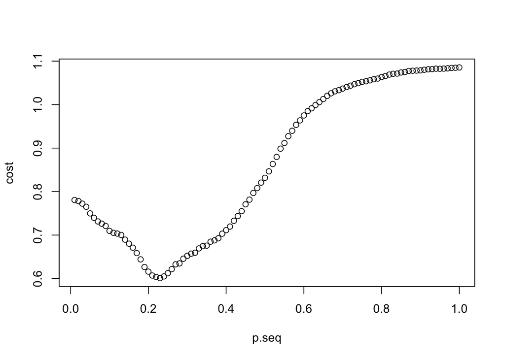

```r
# draw a plot with X axis being all pcut and Y axis being associated cost
plot(p.seq, cost)
```

```r
# find the optimal pcut
optimal.pcut.glm0 = p.seq[which(cost==min(cost))]
```

#### 3.2.2.1 Use the optimal cut-off probability

Now let calculate MR, FPR, FNR, and cost based on the optimal cut-off.

```r
# step 1. get binary classification
class.glm0.train.opt <- (pred.glm0.train>optimal.pcut.glm0)*1
# step 2. get confusion matrix, MR, FPR, FNR
table(credit.train$default, class.glm0.train.opt, dnn = c("True", "Predicted"))
```

```
##     Predicted
## True    0    1
##    0 5667 1849
##    1  784 1300
```

```r
MR <- mean(credit.train$default!= class.glm0.train.opt)
FPR <- sum(credit.train$default==0 & class.glm0.train.opt==1)/sum(credit.train$default==0)
FNR <- sum(credit.train$default==1 & class.glm0.train.opt==0)/sum(credit.train$default==1)
cost <- costfunc(obs = credit.train$default, pred.p = pred.glm0.train, pcut = optimal.pcut.glm0)
```

#### 3.2.2.2 **Exercise 1:**

> 1. Change the weights to different values, and see how your optimal cut-off changes.
> 2. obtain confusion matrix and calculate the (asymmetric) cost based on the optimal cut-off.
> 3. Find optimal cut-off probability using symmetric cost.
> 4. Calculate MR and cost, what do you find?
> 5. Further, rewrite the cost function to make the weights (or the ratio of two weights) as input parameter.
> 6. Use F-score to determine the optimal cut-off.

### 3.2.3 Out-of-sample Classification

Everything you have done about classification so far is for training sample. Now let’s get to testing sample. Keep in mind the principle, **testing sample is only used for evaluating your model’s prediction accuracy**! NO NEED TO CHOOSE CUT-OFF PROBABILITY in this stage.

#### 3.2.3.1 **Exercise 2:**

> 1. Calculate MR, FPR, FNR based on the optimal cut-off you get from training sample with weights (5:1)
> 2. Calculate asymetric cost based on the optimal cut-off you get from training sample with weights (5:1)
> 3. Calculate above statistics based on the cut-off you get from training sample with symmetric weights (1:1)

# 4 Summary

## 4.2 Guide for Assignment

- EDA
- Train logistic model
- Prediction (ROC, AUC; PR, AUC)
- Model comparison using AUC
- Find optimal cut-off based on training sample
- Classification – Obtain the confusion matrix and calculate the MR, asymmetric cost, FPR, Precision, Recall, and F-score for both training and testing sample based on (1) naive cut-off determined by sample proportion; (2) optimal cut-off determined by asymmetric cost; (3) optimal cut-off determined by F-score.
- Build new models by Variable Selection
- Calculate all criteria
- Comprehensive comparison

go to top